# Georgia Election Project

Author

Sejal Govindarao

Published

December 21, 2022

# Introduction

In this analysis walkthrough, we will be looking at Georgia election results by county for U.S. Senate and Governor in 2022 and President in 2020.

```r
#import the GA election data for this assignment

#GA senate
senate_results <- read_excel(here("ga_votes.xlsx"), sheet = "senate")

#GA governor
governor_results <- read_excel(here("ga_votes.xlsx"), sheet = "governor")
```

Two columns in particular to highlight that we’ll use to examine how the Republican Senate and Governor candidates did compared with former President Trump’s performance in 2020:

- **`pct_r_above_trump`**. This column calculates the difference in percentage points between what the 2022 Republican candidate got (`pct_r_2022`) and what Trump got two years earlier (`pct_r_2020`). A negative value means the candidate did worse than Trump, a positive value means they did better.
- **`is_r_above_trump`**. This companion columns is a so-called “flag” column, which provides a Yes/No as to whether the Republican candidate did better or worse than Trump. In other words, is the `pct_r_above_trump` value positive or negative.

# Charts

First, we will examine the GA Senate race in 2022 This bar chart compares the counties in which Republican candidate Hershel Walker did better vs. worse than Trump.

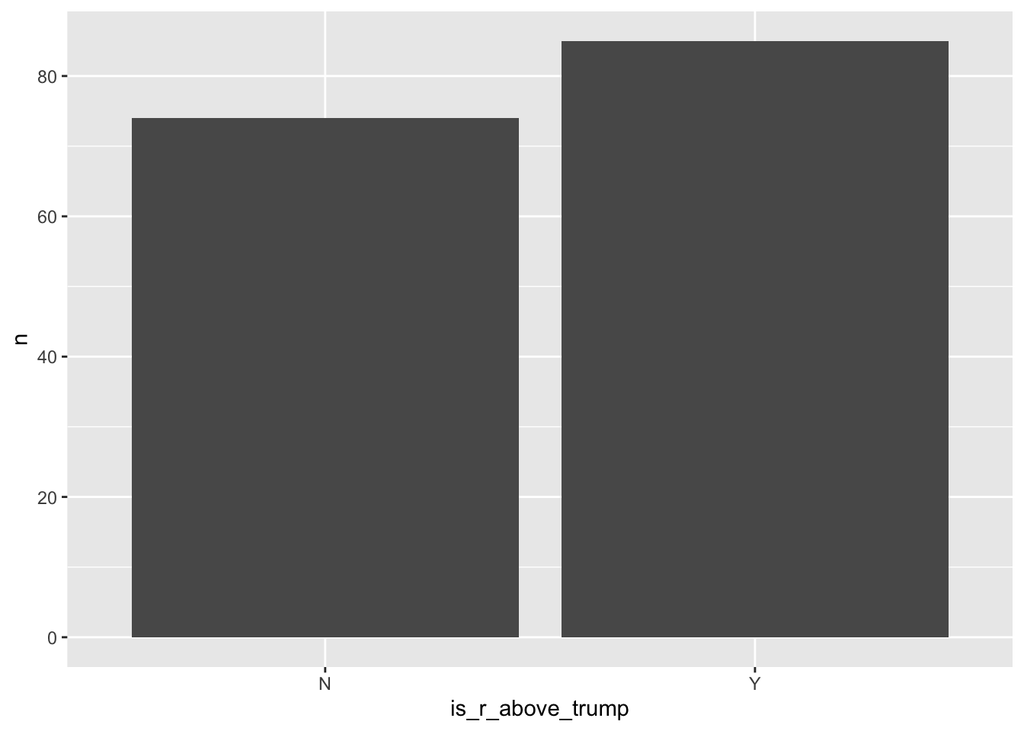

```r
SenateRepublicanCandidateAsComparedToTrump <- senate_results %>%
count(is_r_above_trump)

ggplot(SenateRepublicanCandidateAsComparedToTrump, aes(x = is_r_above_trump, y = n)) +
  geom_col()
```

Next, we will do the same for the GA Gubernatorial race in 2022. This bar chart compares the counties in which Republican candidate Brian Kemp did better vs. worse than Trump.

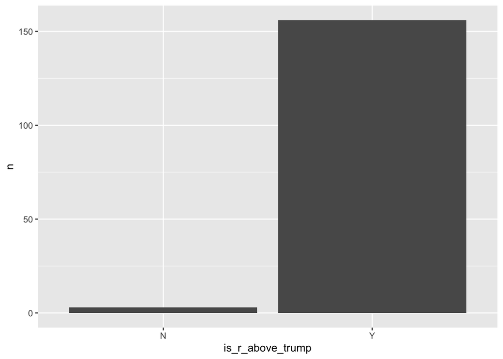

```r
RGovsComparedToTrump <- governor_results %>%
count(is_r_above_trump)

ggplot(RGovsComparedToTrump, aes(x = is_r_above_trump, y = n)) +
  geom_col()
```

Now, again examining the 2022 GA Senate race, this bar chart illustrates the top 10 counties with the biggest drops between Walker and Trump.

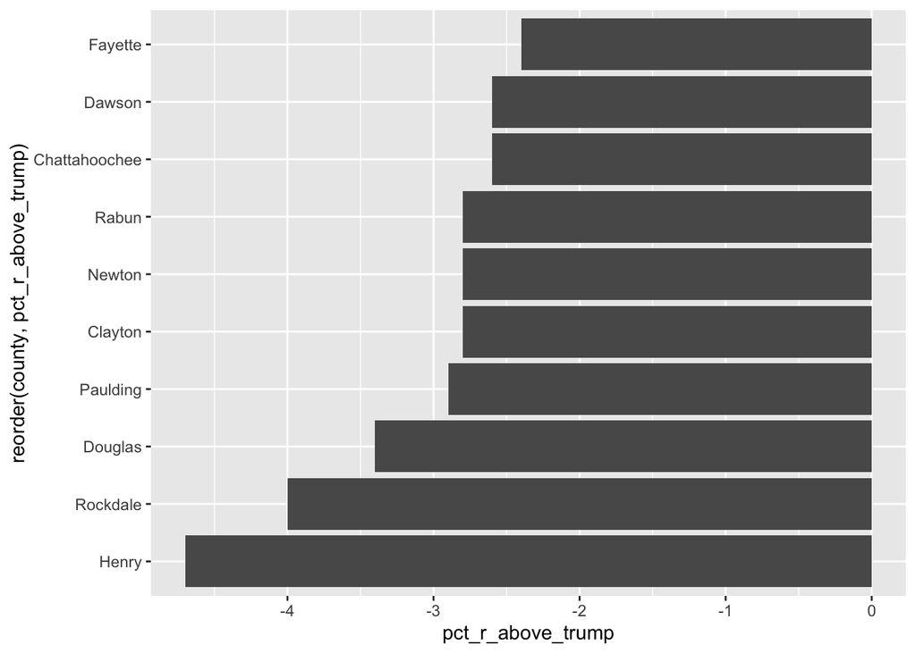

```r
Top10 <- senate_results %>%
  arrange(pct_r_above_trump) %>%
  head(10)

ggplot(Top10, aes(x = reorder(county,pct_r_above_trump), y = pct_r_above_trump)) +
  geom_col() +
  coord_flip()
```

This looks at the top 10 counties in the Senate Race with highest victory margins for Raphael Warnock.

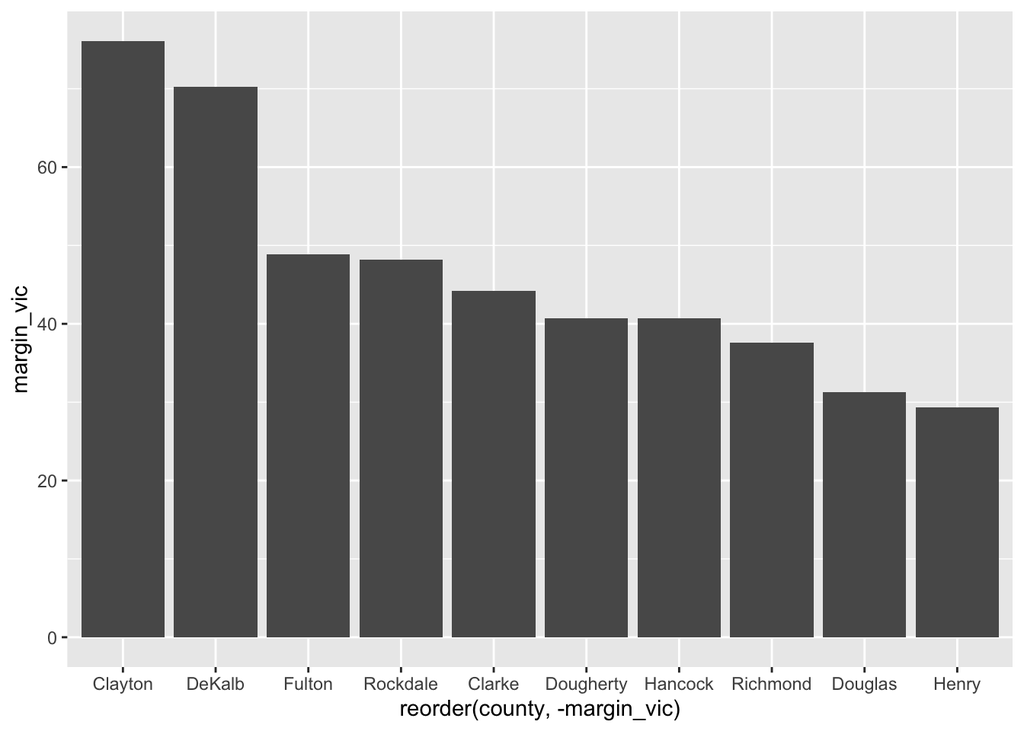

```r
MarginOfVictory <- senate_results %>%
  mutate(margin_vic = (pct_d_2022 - pct_r_2022))

Senate10MOV <- MarginOfVictory %>%
  arrange(desc(margin_vic)) %>% head(10)

ggplot(Senate10MOV, aes(x = reorder(county, -margin_vic), y = margin_vic)) +
  geom_col()
```

This looks at the top 10 counties in the Gubernatorial Race with highest victory margins for Stacey Abrams.

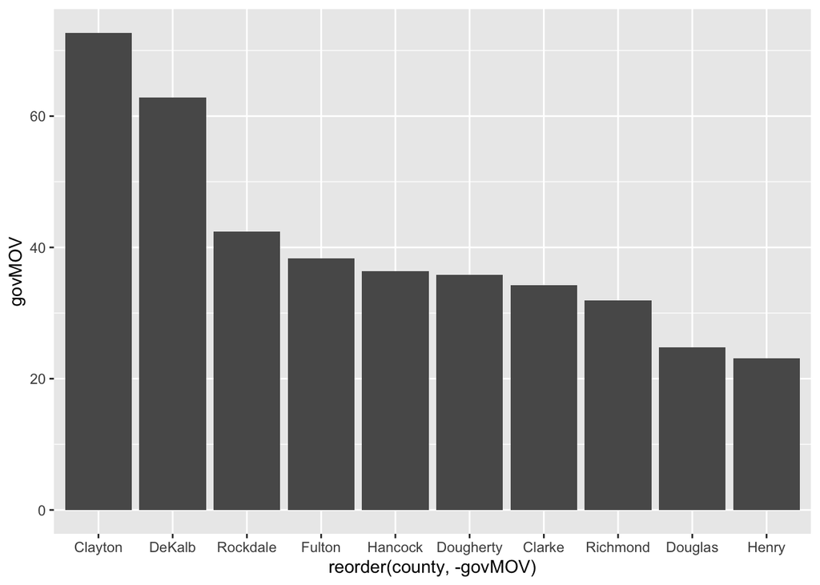

```r
MOV_GOV <- governor_results %>%
  mutate(govMOV = (pct_d_2022 - pct_r_2022))

Gov10MOV <- MOV_GOV %>%
  arrange(desc(govMOV)) %>%  head(10)

ggplot(Gov10MOV, aes(x = reorder(county, -govMOV), y = govMOV)) +
  geom_col()
```

# Maps

```r
counties_geo <- tigris::counties(state = "GA", resolution = "20m", cb = TRUE)
```

Now, we will visualize Georgia counties during the 2022 election!

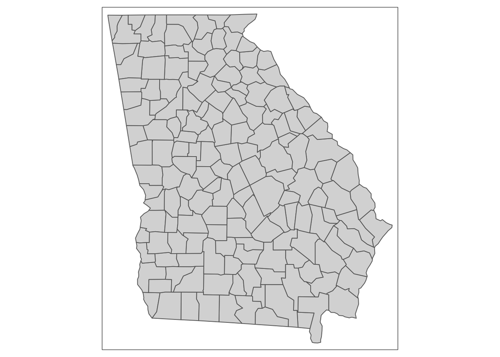

```r
tm_shape(counties_geo) +
  tm_polygons()
```

Here we see a map of Georgia counties where Walker did better vs. worse than Trump.

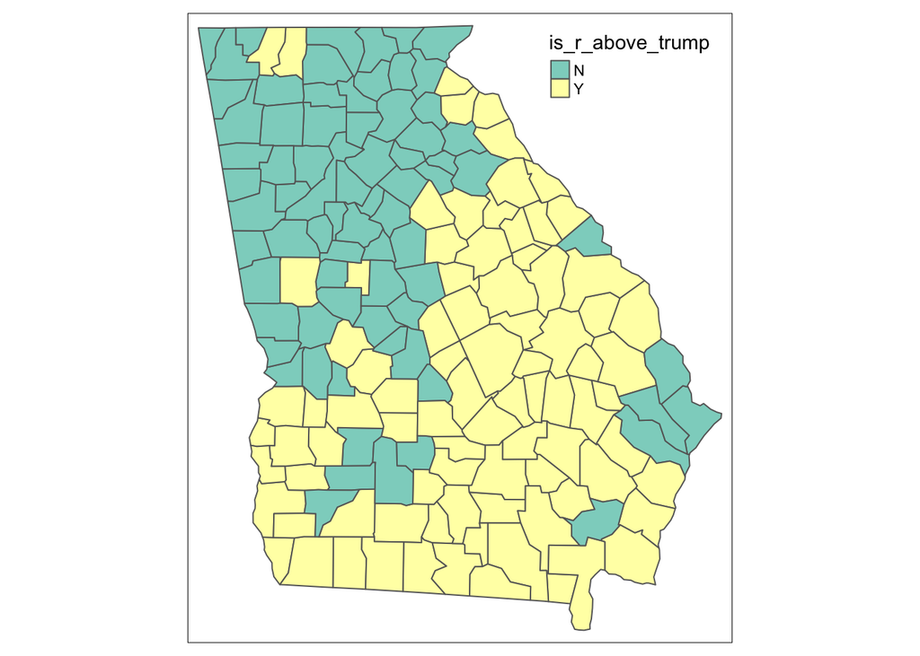

```r
senatemap <- inner_join(counties_geo, senate_results, by = c("GEOID" = "fipsCode"))
tm_shape(senatemap) +
  tm_polygons("is_r_above_trump", id = "GEOID")
```

Switching over to the Gubernatorial race, here we see a map of Georgia counties where Kemp did better vs. worse than Trump.

```r
govmap <- inner_join(counties_geo, governor_results, by = c("GEOID" = "fipsCode"))
tmap_mode(mode = "plot")
```

```
tmap mode set to plotting
```

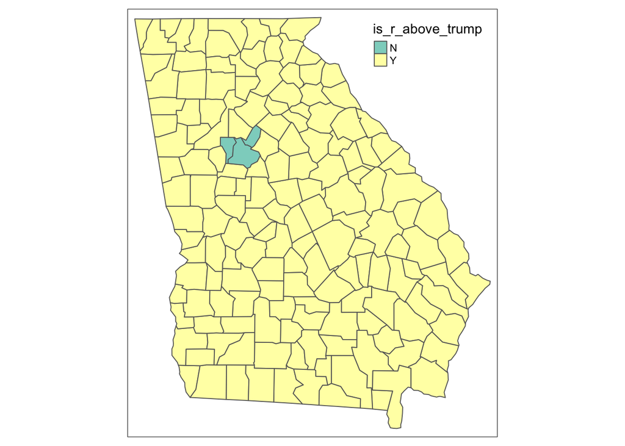

```r
tm_shape(govmap) +
  tm_polygons("is_r_above_trump", id = "GEOID")
```

This map shows us Raphael Warnock’s victory margin per county.

```r
SenVictoryMargins <- inner_join(counties_geo, MarginOfVictory, by = c("GEOID" = "fipsCode"))
tmap_mode(mode = "plot")
```

```
tmap mode set to plotting
```

```
Variable(s) "margin_vic" contains positive and negative values, so midpoint is set to 0. Set midpoint = NA to show the full spectrum of the color palette.
```

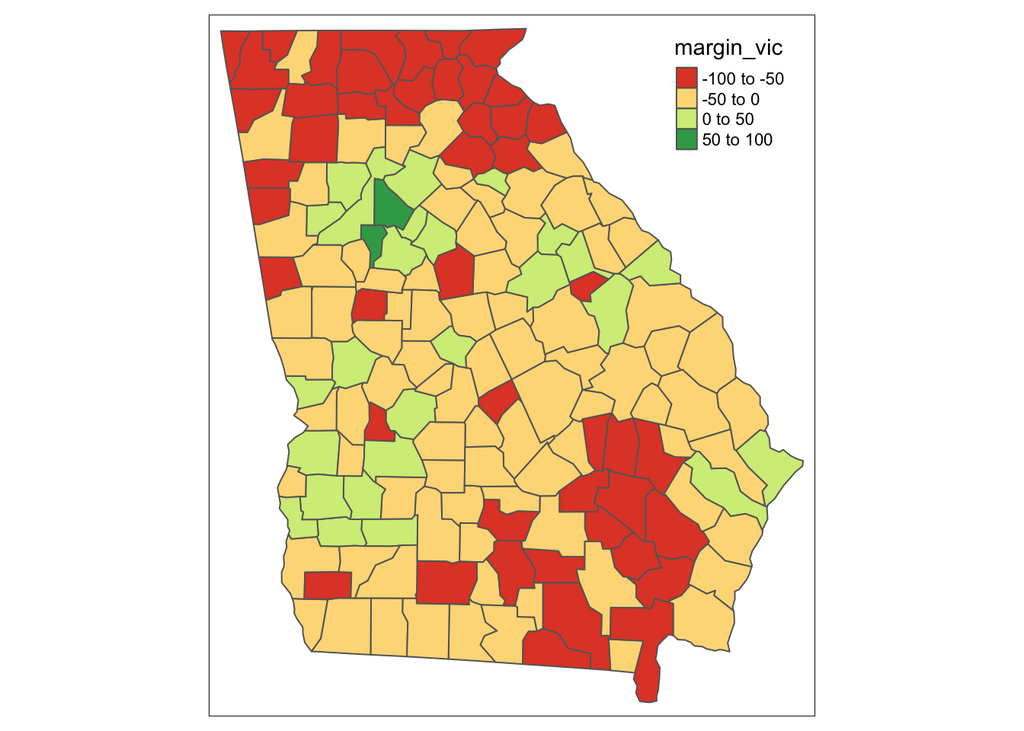

```r
tm_shape(SenVictoryMargins) +
  tm_polygons("margin_vic", id = "GEOID")
```

This map shows us Stacey Abrams’ victory margin per county.

```r
GovChloroMap <- inner_join(counties_geo, MOV_GOV, by = c("GEOID" = "fipsCode"))
tmap_mode(mode = "plot")
```

```
tmap mode set to plotting
```

```
Variable(s) "govMOV" contains positive and negative values, so midpoint is set to 0. Set midpoint = NA to show the full spectrum of the color palette.
```

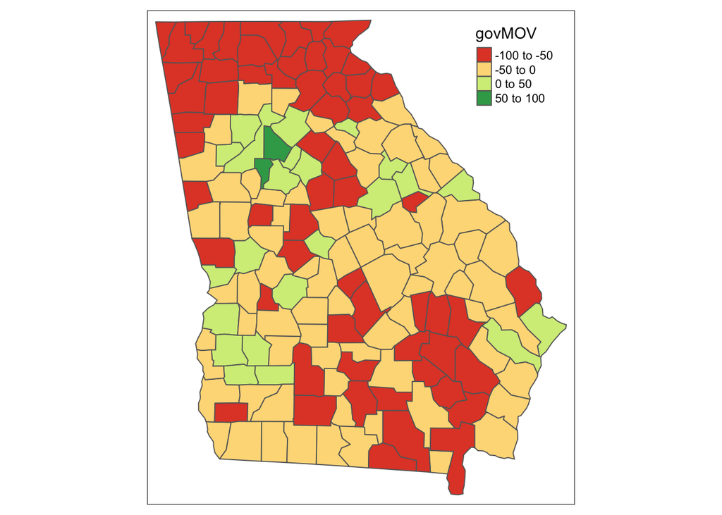

```r
tm_shape(GovChloroMap) +
  tm_polygons("govMOV", id = "GEOID")
```